# Brainstorm: more views on the Innovation Graph × HDI data

## What this notebook is

A scratchpad of **visualization ideas** crossing the GitHub Innovation Graph (`languages.csv`, `topics.csv`, `developers.csv`, `repositories.csv`) with the UN HDI table. The existing notebooks (`languages_by_hdi.qmd`, `topics_by_hdi.qmd`) only touch `hdi_2022` and ignore most of the columns in `hdi.csv`. Plenty of unexplored angles below — pick the ones worth turning into proper charts.

Every section is a single short chunk producing one figure. None of these are polished — they’re sketches.

```r
library(tidyverse)
library(scales)
library(countrycode)

theme_set(theme_minimal(base_size = 11))
```

```r
langs   <- read_csv("languages.csv",   show_col_types = FALSE) |>
  filter(iso2_code != "EU")
topics  <- read_csv("topics.csv",      show_col_types = FALSE) |>
  filter(iso2_code != "EU", !topic %in% c("config", "github-config"))
devs    <- read_csv("developers.csv",  show_col_types = FALSE) |>
  filter(iso2_code != "EU")
repos   <- read_csv("repositories.csv", show_col_types = FALSE) |>
  filter(iso2_code != "EU")
hdi_raw <- read_csv("hdi.csv",         show_col_types = FALSE)

hdi <- hdi_raw |>
  transmute(
    iso2_code = countrycode(iso3, "iso3c", "iso2c"),
    country, region,
    hdi_tier   = factor(hdicode, levels = c("Low", "Medium", "High", "Very High")),
    hdi_1990, hdi_2022,
    hdi_delta  = hdi_2022 - hdi_1990,
    gnipc_2022, mys_2022, eys_2022, le_2022
  ) |>
  filter(!is.na(iso2_code), !is.na(hdi_2022))

latest <- langs |> slice_max(year * 10 + quarter, n = 1) |>
  distinct(year, quarter)

langs_snap  <- langs  |> semi_join(latest, by = c("year", "quarter")) |>
  inner_join(hdi, by = "iso2_code")
topics_snap <- topics |> semi_join(latest, by = c("year", "quarter")) |>
  inner_join(hdi, by = "iso2_code")
devs_snap   <- devs   |> semi_join(latest, by = c("year", "quarter")) |>
  inner_join(hdi, by = "iso2_code")
repos_snap  <- repos  |> semi_join(latest, by = c("year", "quarter")) |>
  inner_join(hdi, by = "iso2_code")
```

## Idea 1: regions, not tiers

The HDI table has a `region` column (SSA, LAC, EAP, ECA, AS, SA, …) that the existing notebooks ignore entirely. Pushers per region for the latest quarter — does the picture look different than the HDI tier view?

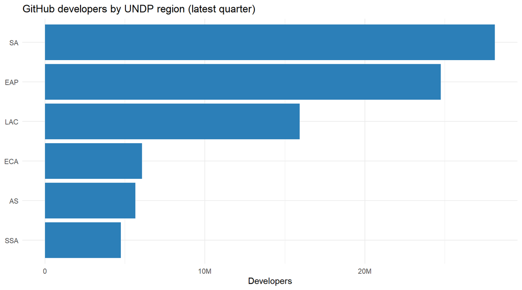

```r
devs_snap |>
  filter(!is.na(region)) |>
  group_by(region) |>
  summarise(developers = sum(developers), .groups = "drop") |>
  ggplot(aes(developers, fct_reorder(region, developers))) +
  geom_col(fill = "#2c7fb8") +
  scale_x_continuous(labels = label_number(scale_cut = cut_short_scale())) +
  labs(title = "GitHub developers by UNDP region (latest quarter)",
       x = "Developers", y = NULL)
```

## Idea 2: HDI change 1990→2022 vs. GitHub footprint

Did countries that *climbed* the HDI ladder over the past three decades end up with bigger or smaller GitHub footprints than their current HDI alone would predict? Each dot is a country.

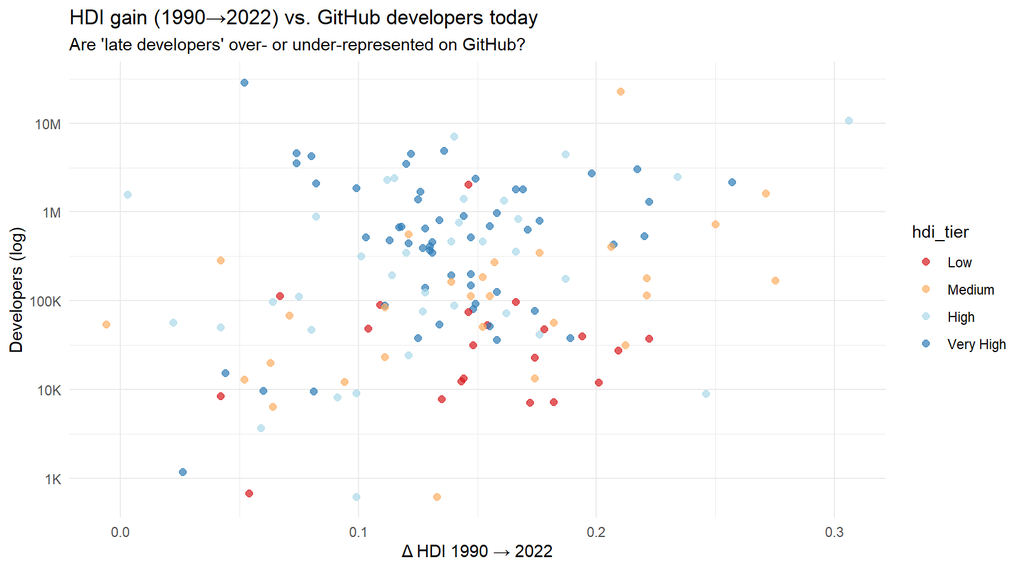

```r
devs_snap |>
  filter(!is.na(hdi_delta), developers > 100) |>
  ggplot(aes(hdi_delta, developers, color = hdi_tier)) +
  geom_point(alpha = 0.7, size = 2) +
  scale_y_log10(labels = label_number(scale_cut = cut_short_scale())) +
  scale_color_brewer(palette = "RdYlBu") +
  labs(title = "HDI gain (1990→2022) vs. GitHub developers today",
       subtitle = "Are 'late developers' over- or under-represented on GitHub?",
       x = "Δ HDI 1990 → 2022", y = "Developers (log)")
```

## Idea 3: GNI per capita as a continuous predictor

HDI tiers are a 4-bucket compression of much richer underlying economics. GNI per capita gives a continuous, log-scaled signal that may separate languages more cleanly than the tier heatmap.

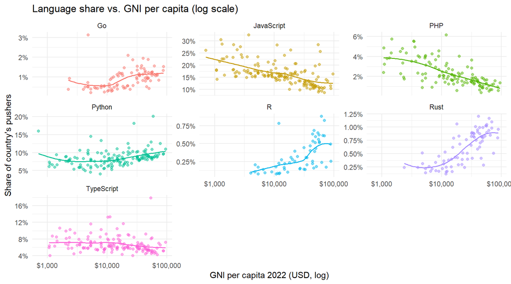

```r
country_totals <- langs_snap |>
  group_by(iso2_code, gnipc_2022) |>
  summarise(total = sum(num_pushers), .groups = "drop")

focus <- c("Python", "JavaScript", "TypeScript", "Rust", "Go", "PHP", "R")

langs_snap |>
  filter(language %in% focus) |>
  group_by(iso2_code, language) |>
  summarise(pushers = sum(num_pushers), .groups = "drop") |>
  inner_join(country_totals, by = "iso2_code") |>
  mutate(share = pushers / total) |>
  filter(total >= 500, !is.na(gnipc_2022)) |>
  ggplot(aes(gnipc_2022, share, color = language)) +
  geom_point(alpha = 0.5, size = 1.5) +
  geom_smooth(se = FALSE, method = "loess", formula = y ~ x, linewidth = 0.6) +
  scale_x_log10(labels = label_dollar()) +
  scale_y_continuous(labels = label_percent()) +
  facet_wrap(~ language, scales = "free_y") +
  labs(title = "Language share vs. GNI per capita (log scale)",
       x = "GNI per capita 2022 (USD, log)", y = "Share of country's pushers") +
  theme(legend.position = "none")
```

## Idea 4: education years vs. developer density

Does **mean years of schooling** track GitHub footprint better than HDI? A single continuous education variable plotted against developer count.

[figure not shown]

```r
devs_snap |>
  filter(!is.na(mys_2022), developers > 100) |>
  ggplot(aes(mys_2022, developers, color = hdi_tier)) +
  geom_point(alpha = 0.7, size = 2) +
  geom_smooth(method = "lm", se = FALSE, color = "grey25",
              linewidth = 0.5, formula = y ~ x) +
  scale_y_log10(labels = label_number(scale_cut = cut_short_scale())) +
  scale_color_brewer(palette = "RdYlBu") +
  labs(title = "Mean years of schooling vs. GitHub developers",
       x = "Mean years of schooling (2022)", y = "Developers (log)")
```

## Idea 5: language type mix per tier

`languages.csv` has a `language_type` column (programming, markup, data, prose) that no notebook touches. What share of each tier’s pushers is on each *kind* of language?

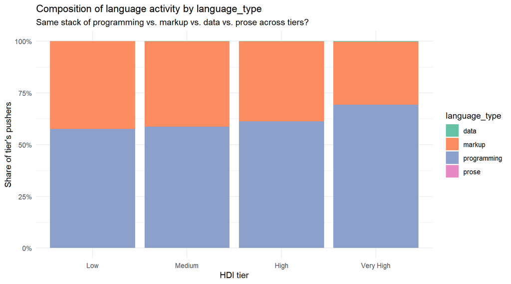

```r
langs_snap |>
  group_by(hdi_tier, language_type) |>
  summarise(pushers = sum(num_pushers), .groups = "drop") |>
  group_by(hdi_tier) |>
  mutate(share = pushers / sum(pushers)) |>
  ggplot(aes(hdi_tier, share, fill = language_type)) +
  geom_col() +
  scale_y_continuous(labels = label_percent()) +
  scale_fill_brewer(palette = "Set2") +
  labs(title = "Composition of language activity by language_type",
       subtitle = "Same stack of programming vs. markup vs. data vs. prose across tiers?",
       x = "HDI tier", y = "Share of tier's pushers")
```

## Idea 6: language diversity (Shannon entropy) per country

How concentrated vs. spread out is each country’s language activity? Low entropy → one or two dominant languages. High entropy → broad mix. Does diversity track with HDI?

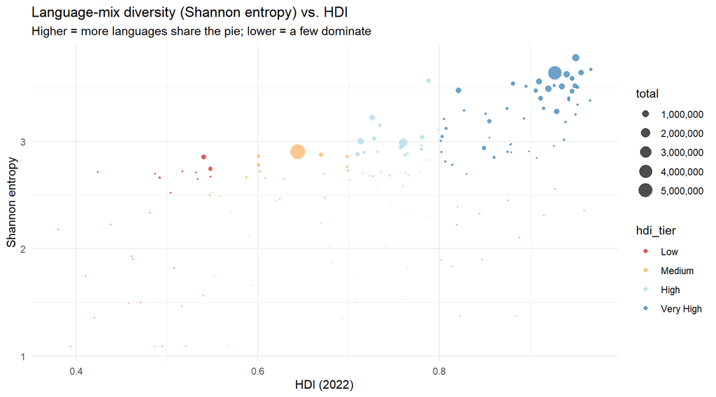

```r
langs_snap |>
  group_by(iso2_code, country, hdi_2022, hdi_tier) |>
  summarise(
    H = {p <- num_pushers / sum(num_pushers); -sum(p * log(p))},
    total = sum(num_pushers),
    .groups = "drop"
  ) |>
  filter(total >= 500) |>
  ggplot(aes(hdi_2022, H, color = hdi_tier, size = total)) +
  geom_point(alpha = 0.7) +
  scale_size_area(max_size = 6, labels = label_comma()) +
  scale_color_brewer(palette = "RdYlBu") +
  labs(title = "Language-mix diversity (Shannon entropy) vs. HDI",
       subtitle = "Higher = more languages share the pie; lower = a few dominate",
       x = "HDI (2022)", y = "Shannon entropy")
```